## **Crescent nail-tail wallaby**

### Blamed on cats

[figure not shown]

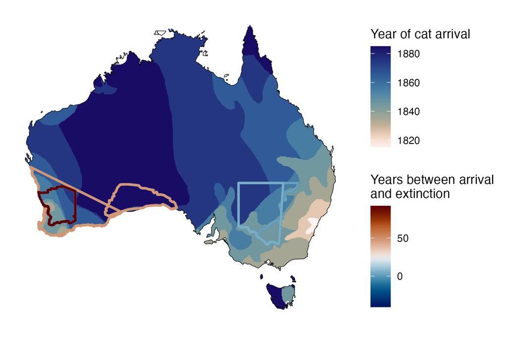

IUCN status: **Extinct**

Last seen: *Onychogalea lunata were last seen in 1952 (1950-1954) in Wheatbelt, WA (IUCN 2023)*

IUCN claim: *“This species was probably extirpated by predation from introduced foxes and cats.”*

### Studies not in support

Crescent nail-tail wallabies were last confirmed in western NSW (two records) 23 years before to 30 years after cats arrived (Wallach and Lundgren 2025).

### Is the threat claim evidence-based?

In one region it cannot be verrified that extirpation occurred after cat arrival, and in another the two species possibly co-occurred for over a century.

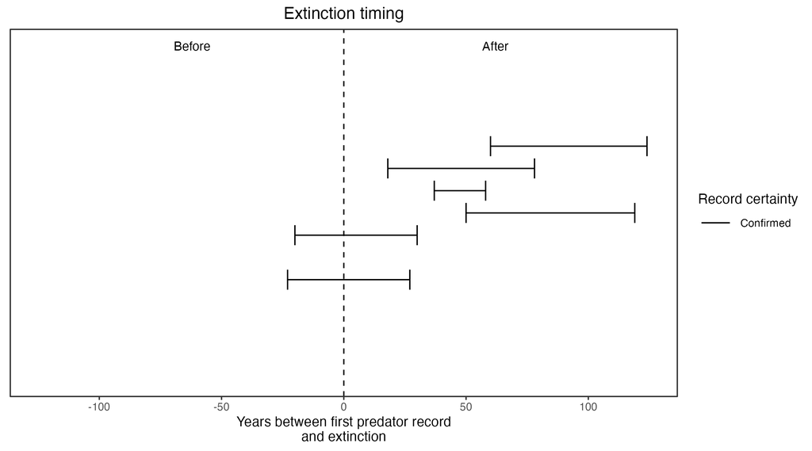

**Evidence linking *Onychogalea lunata* to cats.** Last records of extirpated populations relative to earliest local records of cats. Error bars show record uncertainty range. Predator arrival records were digitized from Abbott 2008.

### References

Abbott, The spread of the cat, Felis catus, in Australia: re-examination of the current conceptual model with additional information. Conservation Science Western Australia 7 (2008).

IUCN Red List. https://www.iucnredlist.org/ Accessed June 2023

Wallach A.D., Lundgren E.J. (2025) Review of evidence that foxes and cats cause extinctions of Australia’s endemic mammals. BioScience. DOI: 10.1093/biosci/biaf046